# Exsperimenter med faste farver

pmd

2021-06-07

# Opgaven

- Stykkerne skal have samme farvekoder – det er næsten umuligt at danne sig et overblik ellers. Vi har lavet et excel-ark. Det er uploaded til Github (håber jeg!!), og er også vedhæftet her (Komedietitler.xlsx).
- Karaktererne ligeså. Vi arbejder på dette og listen kommer snarest.

# Indledning

## Indlæse pakker

Først indlæses [Tidyverse](https://www.tidyverse.org) og alt andet nødvendigt

```r
library("tidyverse")

library(here)
library(ndjson)
library(xslt)
library(fs)
library(ggplot2)
library(readxl)
library(tidytext)
library(readr)  # for read_csv()
library(purrr)  # for map(), reduce()

source(here("src/p017-functions.R"))
```

## Indlæs stykkerne

```r
read_plays_jsonl(here("test-data")) %>% select(filename, everything()) -> plays
```

```
Advarsel i stream_in_int(path.expand(path)) : Parsing error on line 230
```

## Indlæs variant-regnearket

```r
variants <- read_excel(here("Rolleliste.xlsx")) %>%
     unnest_tokens(variant, Alias, token = "regex", pattern = ", ") %>%
    mutate(
      Karakter = tolower(Karakter),
      variant = tolower(variant)
    )
```

## Mellemregninger

### kombiner varianter og stykker

```r
plays %>%
  mutate(speaker = tolower(speaker)) %>%
  left_join(variants, by = c("filename"="Filnavn", "speaker"="variant")) %>%
  mutate(speaker = if_else(!is.na(Karakter), Karakter, speaker)) %>%
  distinct -> plays
```

Vi har nu

```r
plays
```

| filename | act | act_number | docTitle | index | scene | scene_number | speaker | speaker_stage | spoke | stage | title | type | year | Karakter |
| --- | --- | --- | --- | --- | --- | --- | --- | --- | --- | --- | --- | --- | --- | --- |
| Abracadabra_mod.jsonl | Første akt | 1 | Husspøgelse eller Abracadabra Komedie i 3 akter uden aktricer | 1 | Scene 1 | 1 | NA | NA | NA | Arv, Henrik | Husspøgelse | 1 | (1753) | NA |
| Abracadabra_mod.jsonl | Første akt | 1 | Husspøgelse eller Abracadabra Komedie i 3 akter uden aktricer | 2 | Scene 1 | 1 | arv | NA | Denne rejse vil nok have samme udfald som de forrige. Ridefogeden skikker mig til byen for at anholde om ting til gårdens fornødenhed, men når jeg kommer, kan jeg hverken få herren eller tjenerne i ta… | NA | Husspøgelse | 4 | (1753) | NA |
| Abracadabra_mod.jsonl | Første akt | 1 | Husspøgelse eller Abracadabra Komedie i 3 akter uden aktricer | 3 | Scene 1 | 1 | arv | NA | NA | (Han banker stærkt på) | Husspøgelse | 2 | (1753) | NA |
| Abracadabra_mod.jsonl | Første akt | 1 | Husspøgelse eller Abracadabra Komedie i 3 akter uden aktricer | 4 | Scene 1 | 1 | henrik | (ovenfra, med en nathue på hovedet) | NA | NA | Husspøgelse | 3 | (1753) | NA |
| Abracadabra_mod.jsonl | Første akt | 1 | Husspøgelse eller Abracadabra Komedie i 3 akter uden aktricer | 5 | Scene 1 | 1 | henrik | NA | Hvem er så dristig at banke på porten så tidlig om morgenen? | NA | Husspøgelse | 4 | (1753) | NA |
| Abracadabra_mod.jsonl | Første akt | 1 | Husspøgelse eller Abracadabra Komedie i 3 akter uden aktricer | 6 | Scene 1 | 1 | arv | NA | Gid du får en ulykke! Er det tidlig klokken 9 om dagen? | NA | Husspøgelse | 4 | (1753) | NA |
| Abracadabra_mod.jsonl | Første akt | 1 | Husspøgelse eller Abracadabra Komedie i 3 akter uden aktricer | 7 | Scene 1 | 1 | henrik | NA | For fornemme folk er det tidligt. Det er kun gårdskarle og andre gemene slyngler der står op med solen. | NA | Husspøgelse | 4 | (1753) | NA |
| Abracadabra_mod.jsonl | Første akt | 1 | Husspøgelse eller Abracadabra Komedie i 3 akter uden aktricer | 8 | Scene 1 | 1 | arv | NA | Herut af vinkælderen, du fyldehund, hvor du ligger og sylter dig. | NA | Husspøgelse | 4 | (1753) | NA |
| Abracadabra_mod.jsonl | Første akt | 1 | Husspøgelse eller Abracadabra Komedie i 3 akter uden aktricer | 9 | Scene 1 | 1 | arv | NA | NA | (Banker igen) | Husspøgelse | 2 | (1753) | NA |
| Abracadabra_mod.jsonl | Første akt | 1 | Husspøgelse eller Abracadabra Komedie i 3 akter uden aktricer | 10 | Scene 1 | 1 | henrik | NA | Hvad pokker er det for alarm? Mener dit bæst at du er på landet? Fort, pak dig bort fra huset. Hvad har du her at bestille? | NA | Husspøgelse | 4 | (1753) | NA |

[output cut: 990 more lines]

### Opret hjælpe datarammer

```r
# count words in "spoke"
plays %>%
  # remove rows that are not dialogue and empty speakers
  filter(!is.na(spoke), speaker != "") %>%

  # select only the columns, that we are interested in
  select(speaker, title, year, spoke) %>%

  # add the number of spoken words
  mutate(n_spoken_words = str_count(spoke, '\\w+')) %>%
  # remove the spoken words
  select(-spoke) %>%

  # group by title and speaker
  group_by(title, year, speaker) %>%

  # Sum the words spoken by each speaker in each play
  # Lastly store the new data frame in a new reference for later use
  summarise(words = sum(n_spoken_words), title, year) %>%
  ##    ungroup() %>%
  distinct() -> summary
summary %>%
    ungroup(speaker) %>%
    summarise(words_play = sum(words)) -> totals
summary %>%
  full_join(totals) %>%
  summarise(
    freq = words / words_play,
    speaker,
    title,
    year,
    words,
    words_play) %>%
  ungroup() -> summary
```

```r
summary %>%
    ## filter(speaker %in%   c("henrik", "jeronimus", "leander")) %>%
    mutate(title_fct2 = str_c(title," ", year)) -> summary_with_yeartitle

summary_with_yeartitle %>%
    arrange(year) %>%
    distinct(title_fct2) %>%
    pull(title_fct2) -> factor_levels_2

#factor_levels_2

summary_with_yeartitle %>%
    mutate(title_fct2 = factor(title_fct2, factor_levels_2)) -> summary_fct2
```

# Faste farver for skikkelser

## Hvor meget siger Jeromimus og Leander?

Som et eksempel, vil jeg illustrere hvor meget Jeronimus og Leander siger

Vi vælger disse farver for de to skikkelser

```r
rolle_farver <- c(
  "jeronimus" = "orange",
  "leander" = "steelblue",
  "leonora" = "red"
)
```

Med disse farver, kan vi nu lave illustrationen

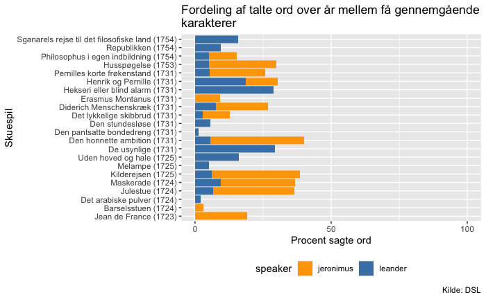

```r
summary_fct2 %>%
  filter(speaker %in%   c("jeronimus", "leander")) %>%
  ggplot(aes(fill = speaker, y = 100*freq, x = title_fct2)) +
    geom_bar(stat="identity") +
  theme(legend.position="bottom") +
  labs(
    title = "Fordeling af talte ord over år mellem få gennemgående\nkarakterer",
    ## subtitle = toupper("TEST"),
    caption = "Kilde: DSL"
  ) +
  scale_fill_manual(values = rolle_farver) +
  scale_y_continuous(limits = c(0,100), breaks = c(0,50,100)) +
  xlab("Skuespil") +
  ylab("Procent sagte ord") +
  coord_flip()
```

Vi kan nu lave en anden sammenligning mellem fx Leonora og Leander, hvor Leander har samme farve som herover (Steel Blue).

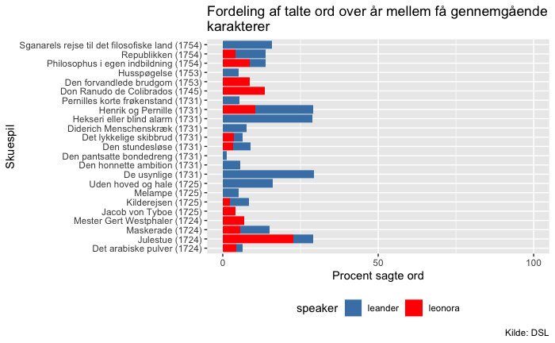

```r
summary_fct2 %>%
  filter(speaker %in%   c("leonora", "leander")) %>%
  ggplot(aes(fill = speaker, y = 100*freq, x = title_fct2)) +
    geom_bar(stat="identity") +
  theme(legend.position="bottom") +
  labs(
    title = "Fordeling af talte ord over år mellem få gennemgående\nkarakterer",
    ## subtitle = toupper("TEST"),
    caption = "Kilde: DSL"
  ) +
  scale_fill_manual(values = rolle_farver) +
  scale_y_continuous(limits = c(0,100), breaks = c(0,50,100)) +
  xlab("Skuespil") +
  ylab("Procent sagte ord") +
  coord_flip()
```

# Faste farver for skuespil

Hvilken illustration vil være fin til at illustrere dette?

Fra Ulla:

> Ang. komediefarver, så er det i visualisering af ord sagt 2 (se slide 16 og 15), hvor det er helt umuligt at sammenligne graferne på tværs, når stykkerne har forskellige farver – den første røde farve dækker fx over 5 forskellige stykker på slide 16 med de seks karakterers optrædener over tid.

## Eksempel af visualiseringer af ord sagt

Det her følgende eksempel er taget fra `visualiseringer-ord-sagt2.Rmd`. Først skal der defineres en hjælpefunktion. Denne funktion er dog afhængig af den globale variabel `new_summary`. (Bmrk.: jeg tager ikek farvekode med)

```r
# count words in "spoke"
(plays %>%
  # remove rows that are not dialogue and empty speakers
  filter(!is.na(spoke), speaker != "") %>%

  # select only the columns, that we are interested in
  select(speaker, title, year, spoke) %>%

  # add the number of spoken words
  mutate(n_spoken_words = str_count(spoke, '\\w+')) %>%
  # remove the spoken words
  select(-spoke) %>%

  # group by title and speaker
  group_by(title, year, speaker) %>%

  # Sum the words spoken by each speaker in each play
  # Lastly store the new data frame in a new reference for later use
  summarise(words = sum(n_spoken_words), title, year) %>%
    distinct() -> my_summary
)
```

| title | year | speaker | words |
| --- | --- | --- | --- |
| Barselsstuen | (1724) | 1. advokat | 154 |
| Barselsstuen | (1724) | 1. dame | 932 |
| Barselsstuen | (1724) | 1. mand | 14 |
| Barselsstuen | (1724) | 1. officer | 181 |
| Barselsstuen | (1724) | 2. advokat | 187 |
| Barselsstuen | (1724) | 2. dame | 583 |
| Barselsstuen | (1724) | 2. mand | 35 |
| Barselsstuen | (1724) | 2. officer | 442 |
| Barselsstuen | (1724) | abelone | 73 |
| Barselsstuen | (1724) | ammen | 47 |

[output cut: 565 more lines]

```r
   # Calculate %
(my_summary %>%
    ungroup(speaker) %>%
    summarise(words_play = sum(words)) -> totals)
```

| title | year | words_play |
| --- | --- | --- |
| Barselsstuen | (1724) | 20695 |
| De usynlige | (1731) | 9703 |
| Den 11. juni | (1724) | 14678 |
| Den danske komedies ligbegængelse | (1746) | 1235 |
| Den forvandlede brudgom | (1753) | 4625 |
| Den honnette ambition | (1731) | 9561 |
| Den pantsatte bondedreng | (1731) | 7658 |
| Den politiske kandestøber | (1723) | 12847 |
| Den stundesløse | (1731) | 15784 |
| Den vægelsindede | (1723) | 13296 |

[output cut: 25 more lines]

```r
(my_summary %>%
  full_join(totals) %>%
  summarise(freq = words / words_play, speaker, title, year, words, words_play) ->
    new_summary)
```

| title | year | speaker | freq | words | words_play |
| --- | --- | --- | --- | --- | --- |
| Barselsstuen | (1724) | 1. advokat | 0.0074414110 | 154 | 20695 |
| Barselsstuen | (1724) | 1. dame | 0.0450350326 | 932 | 20695 |
| Barselsstuen | (1724) | 1. mand | 0.0006764919 | 14 | 20695 |
| Barselsstuen | (1724) | 1. officer | 0.0087460739 | 181 | 20695 |
| Barselsstuen | (1724) | 2. advokat | 0.0090359990 | 187 | 20695 |
| Barselsstuen | (1724) | 2. dame | 0.0281710558 | 583 | 20695 |
| Barselsstuen | (1724) | 2. mand | 0.0016912298 | 35 | 20695 |
| Barselsstuen | (1724) | 2. officer | 0.0213578159 | 442 | 20695 |
| Barselsstuen | (1724) | abelone | 0.0035274221 | 73 | 20695 |
| Barselsstuen | (1724) | ammen | 0.0022710800 | 47 | 20695 |

[output cut: 565 more lines]

```r
character_plot <- function(character_name) {
  new_summary %>%
  filter(speaker == character_name) %>%
  arrange(year) %>%
  ggplot(aes(fill = title, y = freq, x = title)) + #, colour = farvekode
    geom_bar(stat="identity") +
    theme(legend.position="bottom") +
    labs(
      title = "Procent talte ord over år og komedier",
      subtitle = toupper(character_name),
      caption = "Kilde: DSL"
    ) +
  xlab("year") +
  ylab("Procent sagte ord") +
  facet_wrap(~year, ncol=nrow(new_summary), switch="x") +
  theme(axis.text.x=element_blank())
}
```

### Herefter kan vi visualisere, hvor meget Pernille siger

```
Advarsel: 'switch' er forældet.
Brug 'strip.position' i stedet for.
Se help("Deprecated")
```

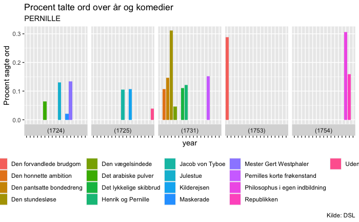

```r
character_plot ("pernille")
```

### Dette kan sammenlignes med hvor meget Leonora siger

```
Advarsel: 'switch' er forældet.
Brug 'strip.position' i stedet for.
Se help("Deprecated")
```

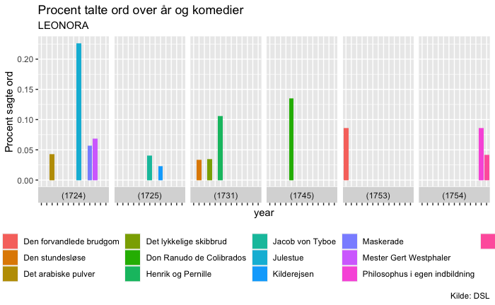

```r
character_plot ("leonora")
```

Udfordringen ligger nu at få stykkerne til at have de samme farver.

Jeg tænker at løse dette ved at lave en farvepalette, som indholder en farve pr. stykke og så bruge den hver gang.

### Faste farver

Ved roller, benytter jeg

```r
rolle_farver <- c(
  "jeronimus" = "orange",
  "leander" = "steelblue",
  "leonora" = "red"
)
```

```r
typeof(rolle_farver)
```

```
[1] "character"
```

```r
rolle_farver[1]
```

```
jeronimus
 "orange"
```

```r
typeof(.Last.value)
```

```
[1] "character"
```

og i selve ggplot kommandoen: `scale_fill_manual(values = rolle_farver)`. Dvs. jeg skal lave en liste, hvor jeg sammenfletter disse 33 skuespiltitler

```r
plays |> select(title) |> distinct(title) |> pull(title)
```

```
 [1] "Husspøgelse"                              "Barselsstuen"
 [3] "Den pantsatte bondedreng"                 "Den forvandlede brudgom"
 [5] "De usynlige"                              "Den 11. juni"
 [7] "Den honnette ambition"                    "Den stundesløse"
 [9] "Den vægelsindede"                         "Det arabiske pulver"
[11] "Diderich Menschenskræk"                   "Erasmus Montanus"
[13] "Mester Gert Westphaler"                   "Henrik og Pernille"
[15] "Hekseri eller blind alarm"                "Jacob von Tyboe"
[17] "Jean de France"                           "Jeppe på Bjerget"
[19] "Julestue"                                 "Den politiske kandestøber"
[21] "Kilderejsen"                              "Den danske komedies ligbegængelse"
[23] "Maskerade"                                "Melampe"
[25] "Pernilles korte frøkenstand"              "Philosophus i egen indbildning"
[27] "Plutus"                                   "Don Ranudo de Colibrados"
[29] "Republikken"                              "Sganarels rejse til det filosofiske land"
[31] "Det lykkelige skibbrud"                   "Ulysses von Ithacia"
[33] "Uden hoved og hale"
```

med 33 forskellige farver

```r
qualitative_hcl(33, palette = "Dark 3")
```

```
 [1] "#E16A86" "#DD6F72" "#D8755D" "#D17B44" "#C88122" "#BD8700" "#B28D00" "#A49200" "#949700"
[10] "#829C00" "#6CA000" "#50A315" "#20A73C" "#00A956" "#00AB6B" "#00AD7F" "#00AD91" "#00ADA2"
[19] "#00ABB2" "#00A9C0" "#00A5CC" "#00A0D6" "#009ADE" "#5592E4" "#7B8AE6" "#9881E6" "#AF79E2"
[28] "#C071DC" "#CE6AD3" "#D866C7" "#DE63B9" "#E264AA" "#E36699"
```

### Lær at flette lister i R

```r
c( "a" = "Q", "b" = "X")
```

```
  a   b
"Q" "X"
```

```r
x <- c("n1", "n2", "n2")
y <- c("v1", "v2", "v3")
```

```r
y
```

[output not shown]

Heúrēka!

### visualiser med fast farvepalette

Definer den faste palette. Jeg har arbitrært valgt “Dark 3”.

```r
skuespil_titler <- plays |> select(title) |> distinct(title) |> pull(title)
skuespil_farver <- qualitative_hcl(33, palette = "Dark 3")
names(skuespil_farver) = skuespil_titler
skuespil_farver
```

```
                             Husspøgelse                             Barselsstuen
                               "#E16A86"                                "#DD6F72"
                Den pantsatte bondedreng                  Den forvandlede brudgom
                               "#D8755D"                                "#D17B44"
                             De usynlige                             Den 11. juni
                               "#C88122"                                "#BD8700"
                   Den honnette ambition                          Den stundesløse
                               "#B28D00"                                "#A49200"
                        Den vægelsindede                      Det arabiske pulver
                               "#949700"                                "#829C00"
                  Diderich Menschenskræk                         Erasmus Montanus
                               "#6CA000"                                "#50A315"
                  Mester Gert Westphaler                       Henrik og Pernille
                               "#20A73C"                                "#00A956"
               Hekseri eller blind alarm                          Jacob von Tyboe
                               "#00AB6B"                                "#00AD7F"
                          Jean de France                         Jeppe på Bjerget
                               "#00AD91"                                "#00ADA2"
                                Julestue                Den politiske kandestøber
                               "#00ABB2"                                "#00A9C0"
                             Kilderejsen        Den danske komedies ligbegængelse
                               "#00A5CC"                                "#00A0D6"
                               Maskerade                                  Melampe
                               "#009ADE"                                "#5592E4"
             Pernilles korte frøkenstand           Philosophus i egen indbildning
                               "#7B8AE6"                                "#9881E6"
                                  Plutus                 Don Ranudo de Colibrados
                               "#AF79E2"                                "#C071DC"
                             Republikken Sganarels rejse til det filosofiske land
                               "#CE6AD3"                                "#D866C7"
                  Det lykkelige skibbrud                      Ulysses von Ithacia
                               "#DE63B9"                                "#E264AA"
                      Uden hoved og hale
                               "#E36699"
```

Jeg laver nu en ny `character_plot`

```r
character_plot_with_color <- function(character_name, skuespil_farver, skuespil) {
  skuespil %>%
  filter(speaker == character_name) %>%
  arrange(year) %>%
  ggplot(aes(fill = title, y = freq, x = title)) + #, colour = farvekode
    geom_bar(stat="identity") +
    theme(legend.position="bottom") +
    labs(
      title = "Procent talte ord over år og komedier",
      subtitle = toupper(character_name),
      caption = "Kilde: DSL"
    ) +
    scale_fill_manual(values = skuespil_farver) +
    scale_y_continuous(limits = c(0,0.4), breaks = c(0,0.1,0.2,0.3,0.4)) +
    xlab("year") +
    ylab("Procent sagte ord") +
    facet_wrap(~year, ncol=nrow(new_summary), switch="x") +
    theme(axis.text.x=element_blank())
}
```

```r
library(patchwork)
p1 <- character_plot_with_color ("leonora", skuespil_farver, new_summary)
```

```
Advarsel: 'switch' er forældet.
Brug 'strip.position' i stedet for.
Se help("Deprecated")
```

```r
p2 <- character_plot_with_color ("pernille", skuespil_farver, new_summary)
```

```
Advarsel: 'switch' er forældet.
Brug 'strip.position' i stedet for.
Se help("Deprecated")
```

[output not shown]

[figure not shown]

```r
p1 / p2
```

```r
ggsave("farve-eksperiment-leonora-pernille.pdf",
  width = 210,
  height = 297,
  units = "mm")
```

# Indlæsning af farvekoder fra fil

## Farvekoder for skuespil

```r
komedietitler <- read_xlsx(here("Komedietitler.xlsx"))
```

```r
komedietitler |> glimpse()
```

```
Rows: 36
Columns: 5
$ titel           <chr> "Den Politiske Kandstøber", "Den Vægelsindede", "Jean de France", "Jeppe pa…
$ `moderne titel` <chr> "Den politiske kandstøber", "Den Vægelsindede", "Jean de France", "Jeppe pa…
$ årstal          <dbl> 1723, 1723, 1723, 1723, 1723, 1724, 1724, 1724, 1724, 1724, 1724, 1725, 172…
$ farvekode       <dbl> 1, 2, 3, 4, 5, 6, 7, 8, 9, 10, 11, 12, 13, 14, 15, 16, 17, 18, 19, 20, 21, …
$ bemærkninger    <chr> NA, NA, NA, NA, NA, NA, NA, NA, NA, NA, NA, NA, NA, NA, NA, NA, NA, NA, NA,…
```

```r
komedietitler |> select(farvekode) |> distinct(farvekode) |> pull(farvekode)
```

```
 [1]  1  2  3  4  5  6  7  8  9 10 11 12 13 14 15 16 17 18 19 20 21 22 23 24 25 26 27 28 29 30 31 32
[33] 33 34 35 36
```

# Lær om farvepaletter

```r
library("colorspace")
```

[figure not shown]

```
Fejl: `device` must be NULL, a string or a function.
Run `rlang::last_error()` to see where the error occurred.
```

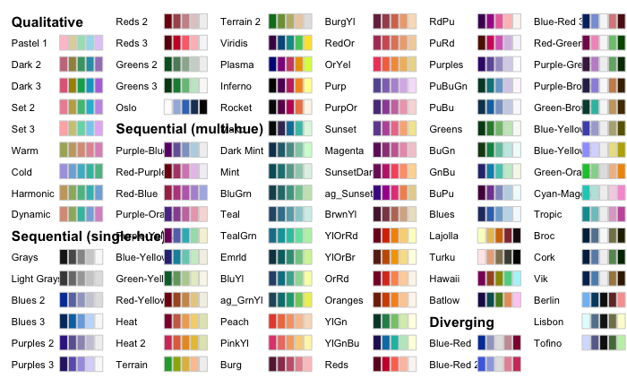

```r
ggsave(hcl_palettes(plot = TRUE),"colors.pdf",
       width = 210,
       height = 297,
       unit = "mm")
```

```r
qualitative_hcl(36, palette = "Dark 3")
```

```
 [1] "#E16A86" "#DE6F74" "#D97460" "#D37A4A" "#CB7F2F" "#C28500" "#B88A00" "#AC8F00" "#9F9400"
[10] "#909800" "#7F9C00" "#6AA000" "#50A315" "#26A63A" "#00A952" "#00AB66" "#00AC79" "#00AD8A"
[19] "#00AD9A" "#00ACA9" "#00AAB7" "#00A8C3" "#00A4CE" "#009FD7" "#009ADE" "#5093E3" "#768BE6"
[28] "#9183E6" "#A87BE4" "#B974DF" "#C86DD7" "#D368CE" "#DA65C3" "#E063B6" "#E264A7" "#E36797"
```

[figure not shown]

[figure not shown]

[figure not shown]